# Taxi Data

AnaPatricia Olvera

7/15/2020

First, the Yellow Taxi data from August2019 and December2019 data is combined:

```r
yellowTaxi <- rbind( read.csv("yellow_tripdata_2019-08.csv"),
                read.csv("yellow_tripdata_2019-12.csv"))
```

Then,the Green Taxi data is combined:

```r
greenTaxi <- rbind( read.csv("green_tripdata_2019-08.csv"),
                read.csv("green_tripdata_2019-12.csv"))
```

Now, the trip duration will be calculated

```r
yellowTaxi$tripduration <- as.duration(interval(yellowTaxi$tpep_pickup_datetime,yellowTaxi$tpep_dropoff_datetime))
```

```r
greenTaxi$tripduration <- as.duration( interval(greenTaxi$lpep_pickup_datetime, greenTaxi$lpep_dropoff_datetime))
```

Next, PickUp DateTime and DropOff DateTime will be separated into PickUp Date/DropOff Date and PickUp time/DropOff Time

```r
yellowTaxi <- yellowTaxi%>% separate(tpep_pickup_datetime, c("pickup.date", "pickup.time"), " ")
yellowTaxi <- yellowTaxi%>% separate(tpep_dropoff_datetime, c("dropoff.date", "dropoff.time"), " ")
```

```r
greenTaxi <- greenTaxi%>% separate(lpep_pickup_datetime, c("pickup.date", "pickup.time"), " ")
greenTaxi <- greenTaxi%>% separate(lpep_dropoff_datetime, c("dropoff.date", "dropoff.time"), " ")
```

Now, the data will be clean a bit: First, omitting all NA values

```r
yellowTaxi <- yellowTaxi%>% na.omit()
```

```r
greenTaxi <- greenTaxi[-17] #elimnates a row full of NAs
greenTaxi <- greenTaxi%>% na.omit()
```

We will only use the data of trips that lasted more than 5 minutes:

```r
yellowTaxi <-yellowTaxi%>% filter( tripduration >= 300 )
```

```r
greenTaxi <- greenTaxi%>% filter(tripduration >= 300)
```

Also, for Rate Code ID we only need to see the values from 1-6:

```r
yellowTaxi <- yellowTaxi%>% filter( RatecodeID >= 1 & RatecodeID <= 6 )
```

```r
greenTaxi <- greenTaxi%>% filter( RatecodeID >=1 & RatecodeID <=6)
```

We need to filter tip amount, since no one can get -100 as tip:

```r
yellowTaxi <- yellowTaxi%>% filter(tip_amount >=0 & tip_amount <=50)
greenTaxi <- greenTaxi%>% filter(tip_amount >=0 & tip_amount<=50)
```

More filtering: -trip distance:

```r
yellowTaxi <- yellowTaxi%>%filter(trip_distance >=0 & trip_distance <=22)
greenTaxi <- greenTaxi%>% filter(trip_distance >=0 & trip_distance <=15)
```

-fare amount

```r
yellowTaxi <- yellowTaxi%>% filter(fare_amount >=0 & fare_amount <=100)
greenTaxi <- greenTaxi%>% filter(fare_amount >=0 & fare_amount <=100)
```

-extra

```r
yellowTaxi <- yellowTaxi%>% filter(extra >=0 )
greenTaxi <- greenTaxi%>% filter(extra >=0 )
```

-MTA tax

```r
yellowTaxi <- yellowTaxi%>% filter(mta_tax >=0 )
greenTaxi <- greenTaxi%>% filter(mta_tax >=0 )
```

-tolls amount

```r
yellowTaxi <- yellowTaxi%>% filter(tolls_amount >=0 )
greenTaxi <- greenTaxi%>% filter(tolls_amount >=0 )
```

-total amount

```r
yellowTaxi <- yellowTaxi%>% filter(total_amount >=0 & total_amount <=200)
greenTaxi <- greenTaxi%>% filter(total_amount >=0 & total_amount <=200)
```

Let’s first find the average trip duration:

```r
mean( yellowTaxi$tripduration,na.rm = T) / 60
```

```
## [1] 20.60132
```

```r
mean( greenTaxi$tripduration, na.rm = T) / 60
```

```
## [1] 22.34135
```

Since payment_type is a numeric value, it will change to a character value following this rule: - 1 = Credit card - 2 = Cash - 3 = No charge - 4 = Dispute - 5 = Unknown - 6 = Voided Trip

```r
payment<- function(a){
  if(a == 1){
    return( "Credit Card" )
  }

  if(a== 2){
    return( "Cash" )
  }

  if(a == 3){
    return( "No Charge" )
  }

  if(a == 4){
    return( "Dispute" )
  }

  if(a == 5){
    return( "Unknown" )
  }

  if(a == 6){
    return( "Voided Trip" )
  }
}
```

Now, payment_type is change:

```r
yellowTaxi$payment_type <- sapply(yellowTaxi$payment_type, payment)
```

```r
greenTaxi$payment_type <- sapply(greenTaxi$payment_type, payment)
```

plotting payment_type:

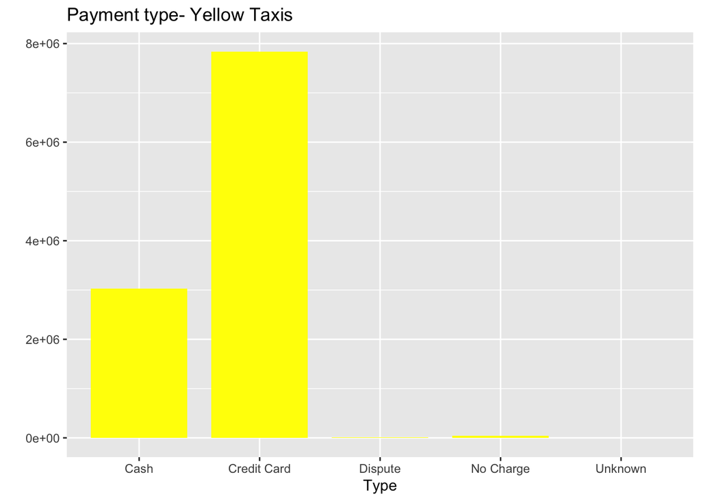

```r
ggplot(yellowTaxi, aes(x= payment_type))+
         geom_bar(stat = "count", width = 0.80, na.rm = T, fill= "yellow" ) + labs( title = "Payment type- Yellow Taxis", x = "Type", y= "")
```

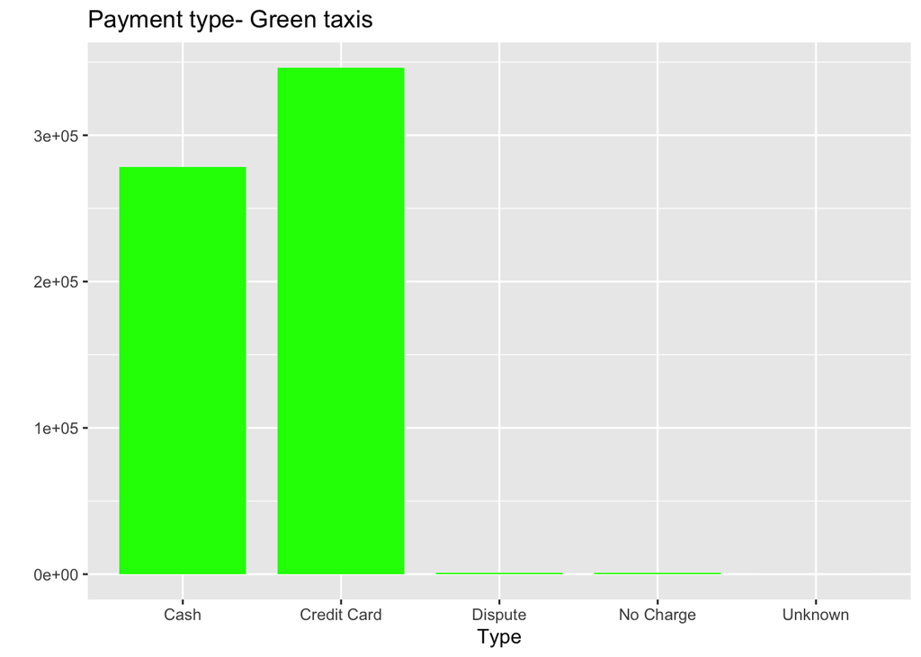

```r
ggplot(greenTaxi, aes(x= payment_type))+
         geom_bar(stat = "count", width = 0.80, na.rm = T, fill= "green" ) + labs( title = "Payment type- Green taxis", x = "Type", y= "")
```

plotting trip type: First, the variable needs to be changed from numerical to character: - 1 = Street-hail - 2 = Dispatch

```r
tripType <- function(t){
  if(t == 1){
    return( "Street-hail")
    }
  if(t == 2){
    return("Dispatch")
    }
}
```

```r
greenTaxi$trip_type <- sapply(greenTaxi$trip_type, tripType)
```

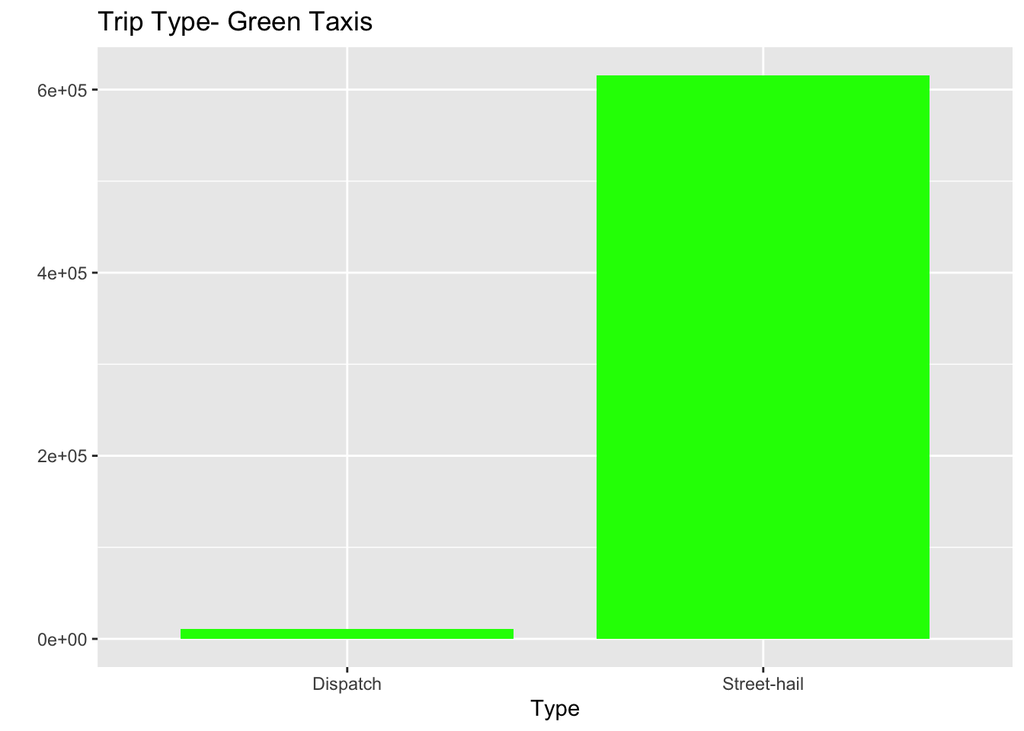

```r
ggplot(greenTaxi, aes(x= trip_type))+
         geom_bar(stat = "count", width = 0.80, na.rm = T, fill= "green" ) + labs( title = "Trip Type- Green Taxis", x = "Type", y= "")
```

plotting vendedorID: - 1 = Creative Mobile Technologies, LLC - 2 = VeriFone Inc.

```r
id <- function(i){
  if(i==1){
    i="LLC"
  }
  else if(i==2){
    i="VeriFone"
  }
  else{
    i="--"
  }
}
```

```r
greenTaxi$VendorID <- sapply(greenTaxi$VendorID, id )
```

```r
yellowTaxi$VendorID <- sapply(yellowTaxi$VendorID, id)
```

plots:

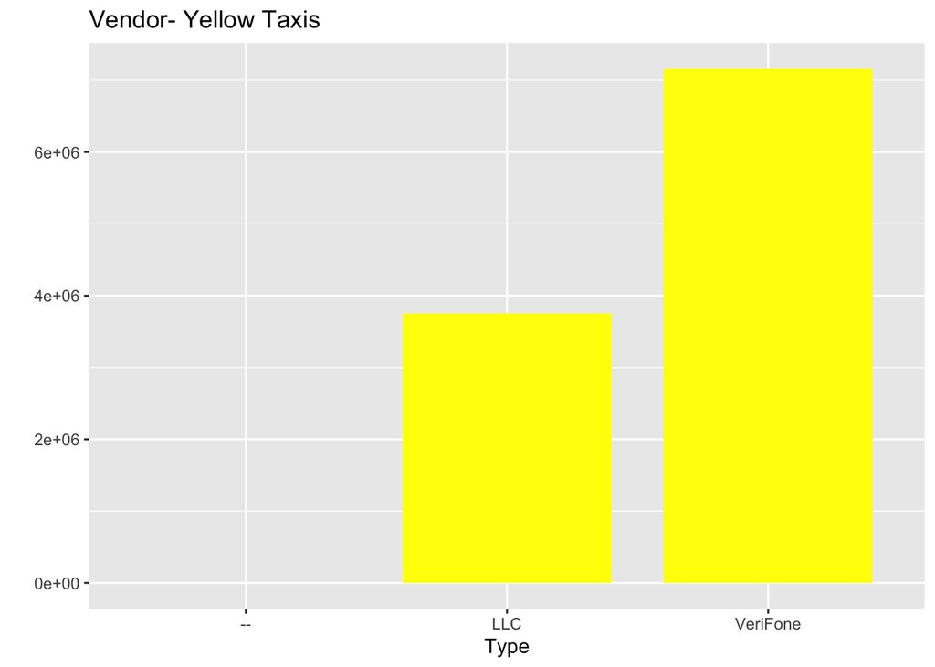

```r
ggplot(yellowTaxi, aes(x= VendorID))+
         geom_bar(stat = "count", width = 0.80, na.rm = T, fill= "yellow" ) + labs( title = "Vendor- Yellow Taxis", x = "Type", y= "")
```

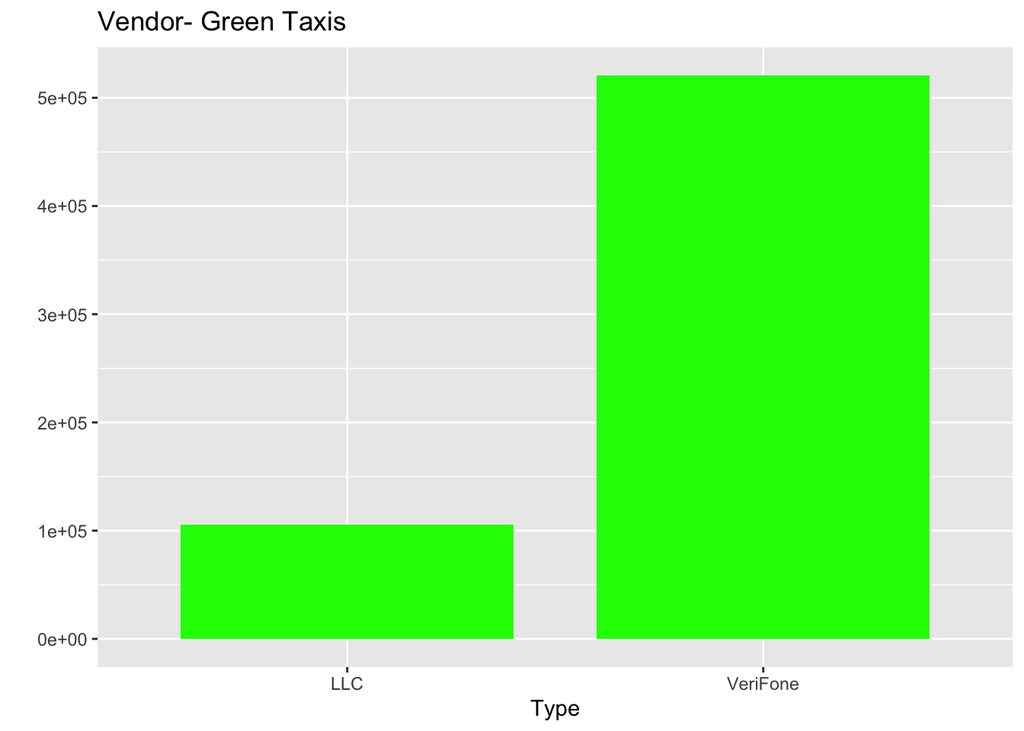

```r
ggplot(greenTaxi, aes(x= VendorID))+
         geom_bar(stat = "count", width = 0.80, na.rm = T, fill= "green" ) + labs( title = "Vendor- Green Taxis", x = "Type", y= "")
```

rate code id: - 1 = standard rate - 2 = JFK - 3 = Newark - 4 = Nassau or Westchester - 5 = Negotiated fare - 6 = Group ride

```r
rateCode <- function(r){
  if( r==1){
    return("Standard rate")
  }
  if( r== 2){
    return("JFK")
  }
  if( r==3 ){
    return("Newark")
  }
  if( r==4 ){
    return("Nassau/Westchester")
  }
  if( r== 5 ){
    return("Negotiated fare")
  }
  if( r==6 ){
    return("Group ride")
  }
}
```

```r
yellowTaxi$RatecodeID <- sapply(yellowTaxi$RatecodeID, rateCode )
```

```r
greenTaxi$RatecodeID <- sapply(greenTaxi$RatecodeID, rateCode )
```

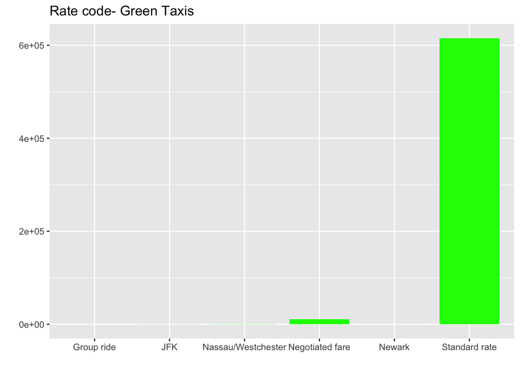

```r
ggplot(greenTaxi, aes(x= RatecodeID))+
         geom_bar(stat = "count", width = 0.80, na.rm = T, fill= "green" ) + labs( title = "Rate code- Green Taxis", x = " ", y= "")
```

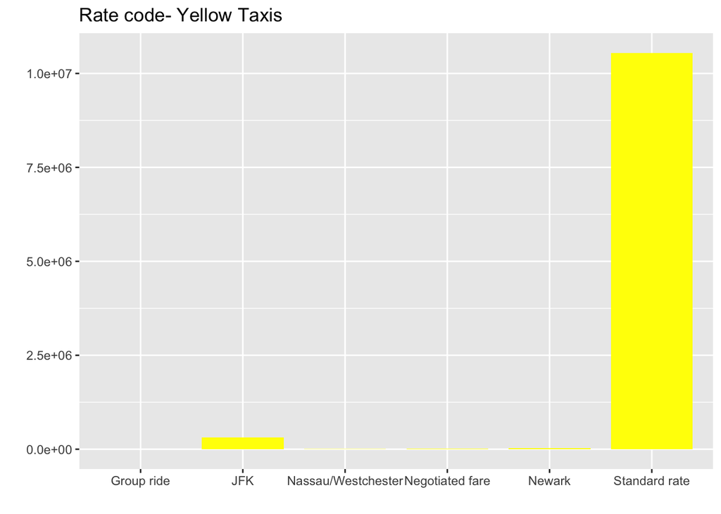

```r
ggplot(yellowTaxi, aes(x= RatecodeID))+
         geom_bar(stat = "count", width = 0.80, na.rm = T, fill= "yellow" ) + labs( title = "Rate code- Yellow Taxis", x = " ", y= "")
```

Let’s create a column with weekdays:

```r
yellowTaxi$weekday <- weekdays(as.Date(yellowTaxi$pickup.date))
```

```r
greenTaxi$weekday <- weekdays(as.Date(greenTaxi$pickup.date))
```

Now, lets plot the week days:

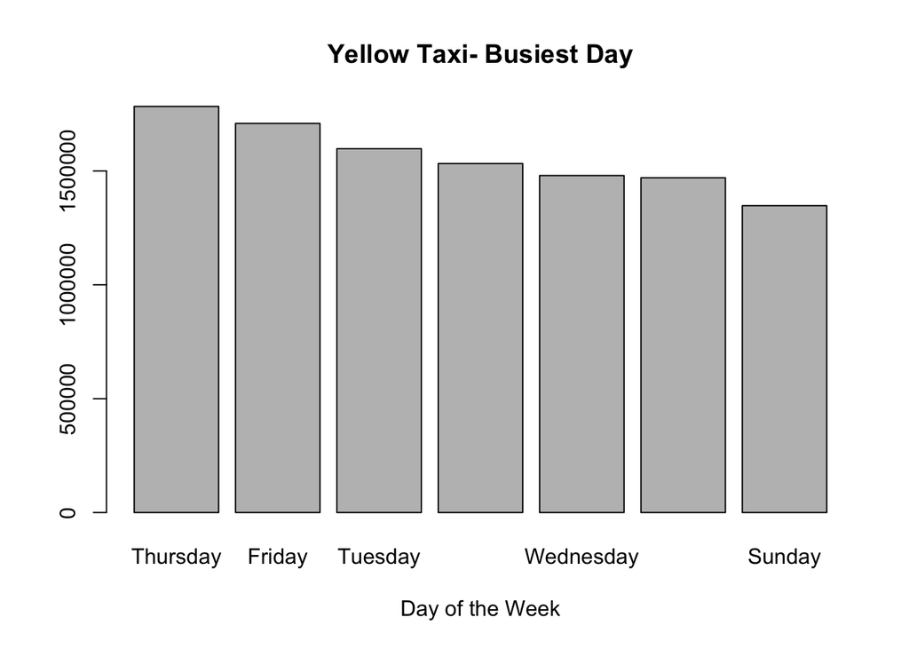

```r
with(diamonds, barplot(rev(sort(table(yellowTaxi$weekday) )[1:7]), width = 10, main= "Yellow Taxi- Busiest Day", xlab= "Day of the Week"))
```

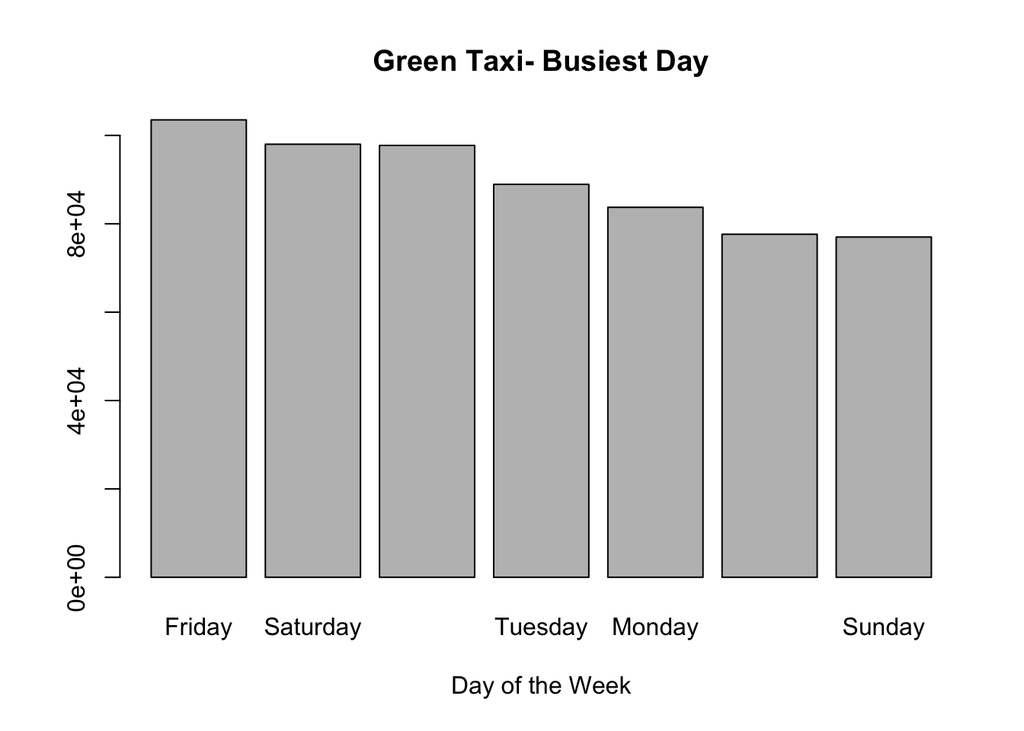

```r
with(diamonds, barplot(rev(sort(table(greenTaxi$weekday) )[1:7]), width = 10, main= "Green Taxi- Busiest Day", xlab= "Day of the Week"))
```

What is average tip drivers receive?

```r
mean( yellowTaxi$tip_amount,na.rm = T)
```

```
## [1] 2.364904
```

```r
mean(greenTaxi$tip_amount, na.rm = T)
```

```
## [1] 1.213638
```

Trip distance:

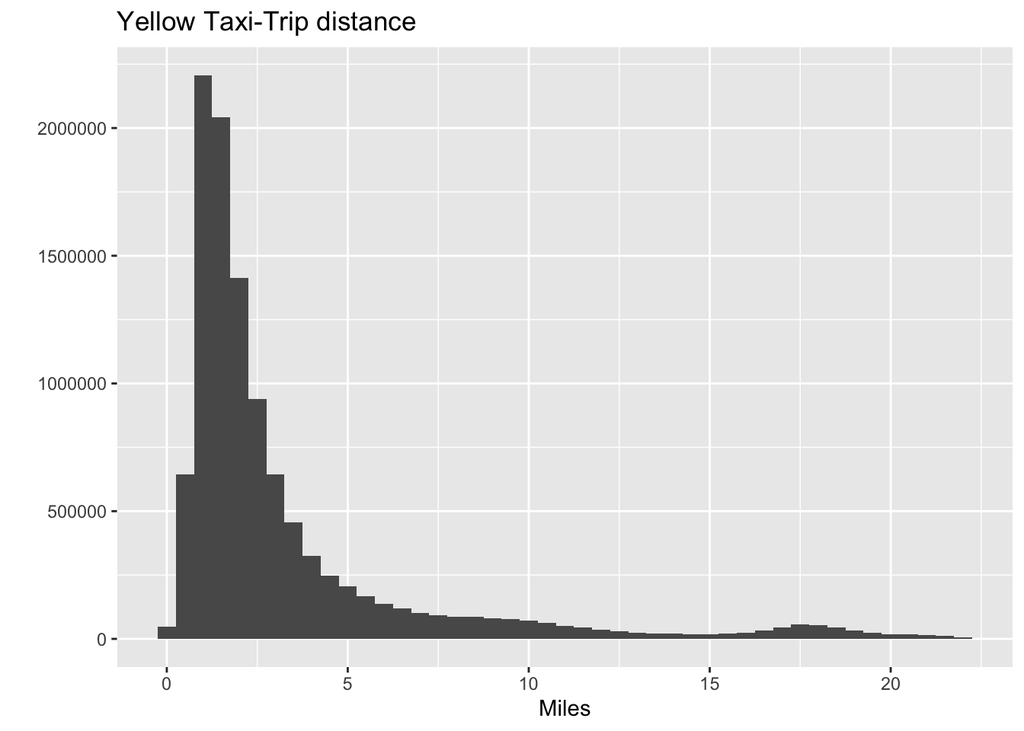

```r
ggplot(yellowTaxi) + geom_histogram(mapping = aes( x= trip_distance), stat = "bin",
  position = "stack", binwidth = 0.5,
  na.rm = T
) + labs( title= "Yellow Taxi-Trip distance", x= "Miles", y= "")
```

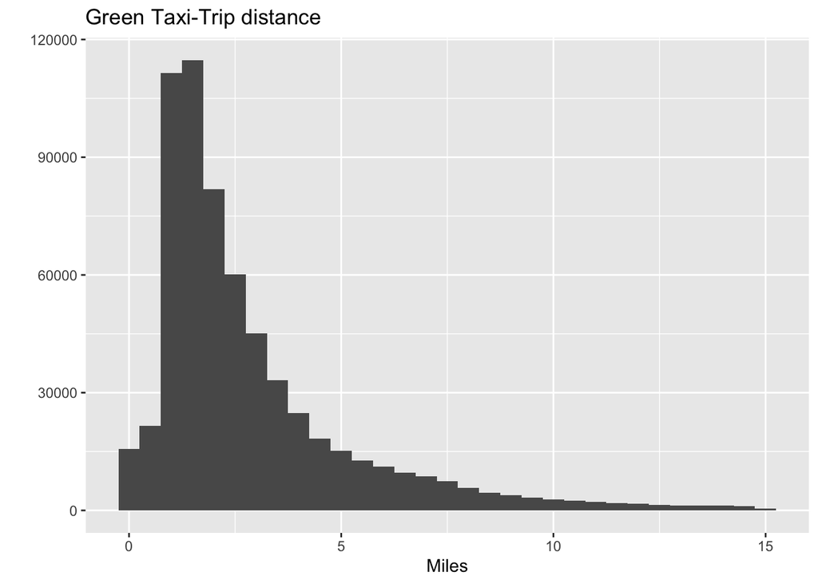

```r
ggplot(greenTaxi) + geom_histogram(mapping = aes( x= trip_distance), stat = "bin",
  position = "stack", binwidth = 0.5,
  na.rm = T
) + labs( title= "Green Taxi-Trip distance", x= "Miles", y= "")
```

What is the average trip distance?

```r
mean(yellowTaxi$trip_distance, na.rm = T)
```

```
## [1] 3.346146
```

```r
mean(greenTaxi$trip_distance, na.rm = T)
```

```
## [1] 2.864584
```

Average total amount:

```r
mean(yellowTaxi$total_amount, na.rm = T)
```

```
## [1] 20.68246
```

```r
mean(greenTaxi$total_amount, na.rm = T)
```

```
## [1] 16.09232
```

Since data from August and December is being used, both data will be compared. First, the Start Date is divided by year, month, and day

```r
yellowTaxi <- yellowTaxi%>% separate(pickup.date, c("year", "month", "day"), "-")
```

```r
greenTaxi <- greenTaxi%>% separate(pickup.date, c("year", "month","day"), "-")
```

The data is filtered and put into separate data frames.

```r
augYellow <- filter(yellowTaxi, month== '08')

decYellow <- filter(yellowTaxi, month== '12')
```

```r
augGreen <- filter(greenTaxi, month== '08')
decGreen <- filter(greenTaxi, month=='12')
```

now let’s plot summer: -Yellow

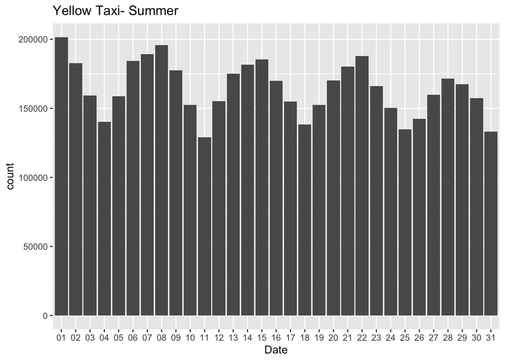

```r
ggplot(augYellow) + geom_bar(aes(x= augYellow$day),stat = "count", na.rm= T)+ labs( title= "Yellow Taxi- Summer", x= "Date")
```

-Green

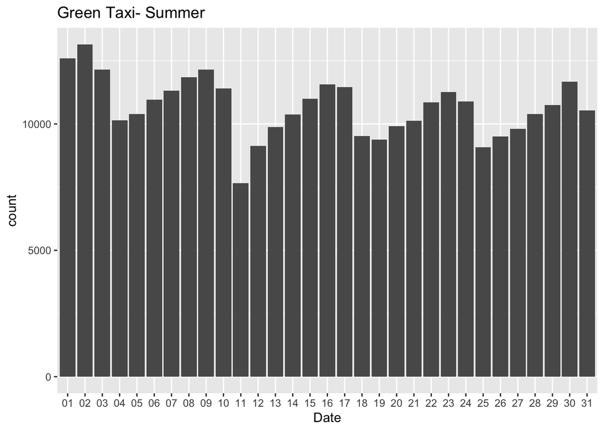

```r
ggplot(augGreen) + geom_bar(aes(x= augGreen$day),stat = "count", na.rm= T)+ labs( title= "Green Taxi- Summer", x= "Date")
```

Now Winter: -Yellow

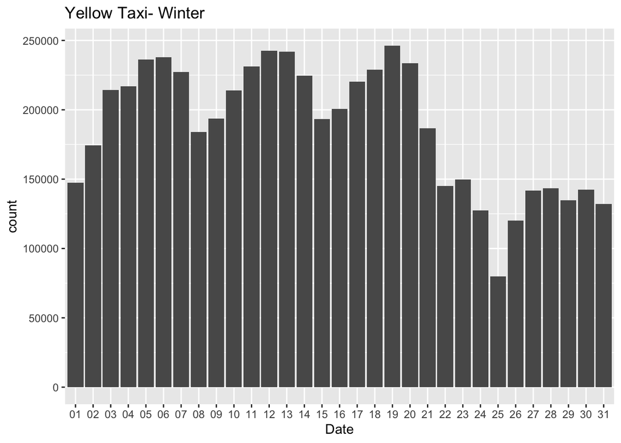

```r
ggplot(decYellow) + geom_bar(aes(x= decYellow$day),stat = "count", na.rm= T)+ labs( title= "Yellow Taxi- Winter", x= "Date")
```

-Green

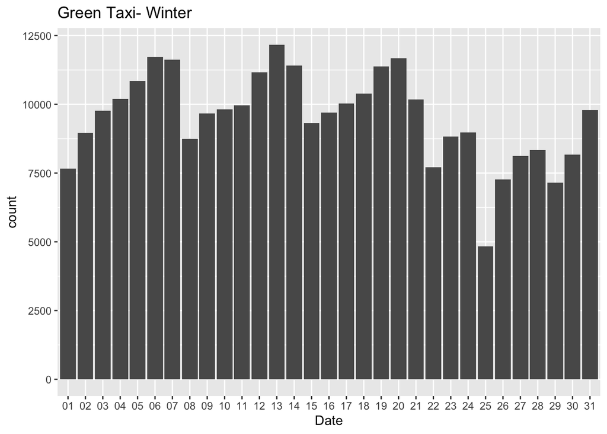

```r
ggplot(decGreen) + geom_bar(aes(x= decGreen$day),stat = "count", na.rm= T)+ labs( title= "Green Taxi- Winter", x= "Date")
```

Now, combining all the graphs: -Yellow Taxi Summer: Orange -Yellow Taxi Winter: Yellow -Green Taxi Summer: Green -Green Taxi Winter: Blue

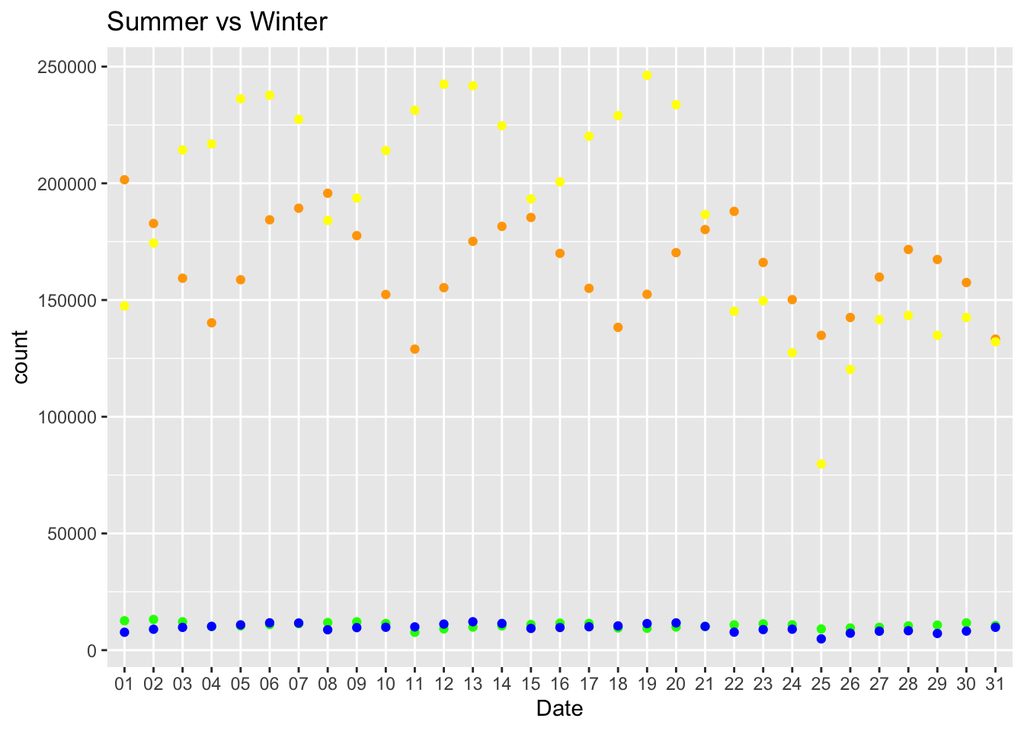

```r
ggplot() +
geom_point(data=augYellow, aes(x=augYellow$day), color='orange', stat = "count", na.rm= T) +
geom_point(data= decYellow, aes(x= decYellow$day), color= 'yellow', stat = "count", na.rm = T)+
geom_point(data= augGreen, aes(x= augGreen$day), color= 'green', stat = "count", na.rm = T)+
geom_point(data= decGreen, aes(x=decGreen$day), color='blue', stat = "count", na.rm= T) +
 labs( title = "Summer vs Winter", x= "Date")
```